# Real.Data

2025-01-28

```r
library(tidyverse)
library(lme4)
library(broom.mixed)
library(magrittr)
```

Read in the growth and survival data

```r
growth = read.csv("../Data/WL2-2023_Size_Combined.csv")
surv = read.csv("../Data/WL2_Mortality.csv")
```

Columns we need in the final data frame for analysis: size, sizeNext, surv (0,1), fec.seed (number of seeds), fec.flower (flowering status,0,1). If suv = 0, then sizeNext is NA.

```r
head(growth)
```

```
##   survey_date block Genotype pop.mf parent.pop mf rep height.cm long.leaf.cm
## 1  2023-07-03  <NA>  CP2_1_1  CP2_1        CP2  1   1       0.5          1.6
## 2  2023-07-03  <NA>  CP2_1_2  CP2_1        CP2  1   2       0.7          1.8
## 3  2023-07-03  <NA>  CP2_1_3  CP2_1        CP2  1   3       1.1          1.8
## 4  2023-07-03  <NA>  CP2_1_4  CP2_1        CP2  1   4       0.8          1.6
## 5  2023-07-03  <NA>  CP2_1_5  CP2_1        CP2  1   5       0.9          1.8
## 6  2023-07-03  <NA>  CP2_1_6  CP2_1        CP2  1   6       1.0          1.9
##   survey.notes
## 1           KN
## 2           KN
## 3           KN
## 4           KN
## 5           KN
## 6           KN
```

```r
head(surv)
```

```
##   block BedLoc bed bed.row bed.col  Genotype  pop.mf parent.pop mf rep
## 1     A  A_1_A   A       1       A  TM2_6_11   TM2_6        TM2  6  11
## 2     A  A_1_B   A       1       B LVTR1_7_1 LVTR1_7      LVTR1  7   1
## 3     A  A_2_A   A       2       A  SQ2_6_14   SQ2_6        SQ2  6  14
## 4     A  A_2_B   A       2       B   YO8_8_3   YO8_8        YO8  8   3
## 5     A  A_3_A   A       3       A    CC_2_3    CC_2         CC  2   3
## 6     A  A_3_B   A       3       B YO11_5_14  YO11_5       YO11  5  14
##   death.date survey.notes
## 1       <NA>         <NA>
## 2    7/26/23         <NA>
## 3    7/26/23         <NA>
## 4    7/26/23         <NA>
## 5       <NA>         <NA>
## 6    7/26/23         <NA>
```

Work with growth first. Going to use start date as 2023-07-26 and end date as 2023-10-20 since both have 1577. Slim data to those dates. This removes some genotypes where first height was measured on a different day.

```r
growth.2 = growth %>%
  filter(survey_date %in% c("2023-07-26","2023-10-20"))
```

All genotypes should have two values, but some have 3 or 4. Looks like some issues with planting.

```r
range(table(growth.2$Genotype))
```

```
## [1] 1 4
```

```r
tail(sort(table(growth.2$Genotype)))
```

```
##
## YO8_8_9 SQ2_6_2  CC_1_2  CC_9_6  IH_4_5  SC_5_6
##       2       3       4       4       4       4
```

Need to remove these odd rows. Not sure how to automate this removal

```r
growth.3 = growth.2[-c(1114,1561,3138,1015,2123,172,1862,1017,2125),]
range(table(growth.3$Genotype))
```

```
## [1] 1 2
```

Remove genotypes where both dates have a height of NA, first height may have been measured on a different date

```r
growth.4 = growth.3 %>%
  group_by(Genotype) %>%
  filter(any(!is.na(height.cm)))
```

Make sure it worked

```r
range(table(growth.4$Genotype))
```

```
## [1] 2 2
```

Need to make the dataframe into wide format. Remove longest leaf and survey notes so data merges better. Checked to see that we do have 1075 unique genotypes which is now the number of rows in growth.6

```r
growth.5 = growth.4 %>%
  select(-long.leaf.cm, -survey.notes)
growth.6 = growth.5 %>%
  pivot_wider(., names_from = survey_date, values_from = height.cm)
```

Remove the 1 row with first survey data as NA

```r
growth.7 = growth.6 %>%
  filter(!is.na(`2023-07-26`))
```

Make a new column for surv

```r
growth.7$surv = ifelse(is.na(growth.7$`2023-10-20`), 0, 1)
```

Change column names to match practice code

```r
colnames(growth.7)[7] = "size"
colnames(growth.7)[8] = "sizeNext"
```

### Plotting

Plotting survival, growth/shrinkage/stasis as a function of our state variable, size.

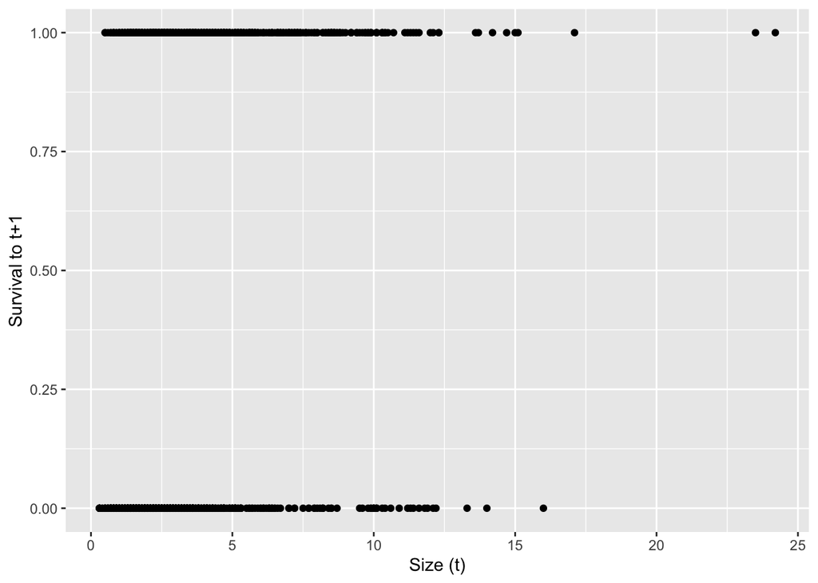

```r
survival.plot=ggplot(growth.7, aes(x = size, y = surv))+
  geom_point()+
  xlab("Size (t)")+
  ylab("Survival to t+1")
survival.plot
```

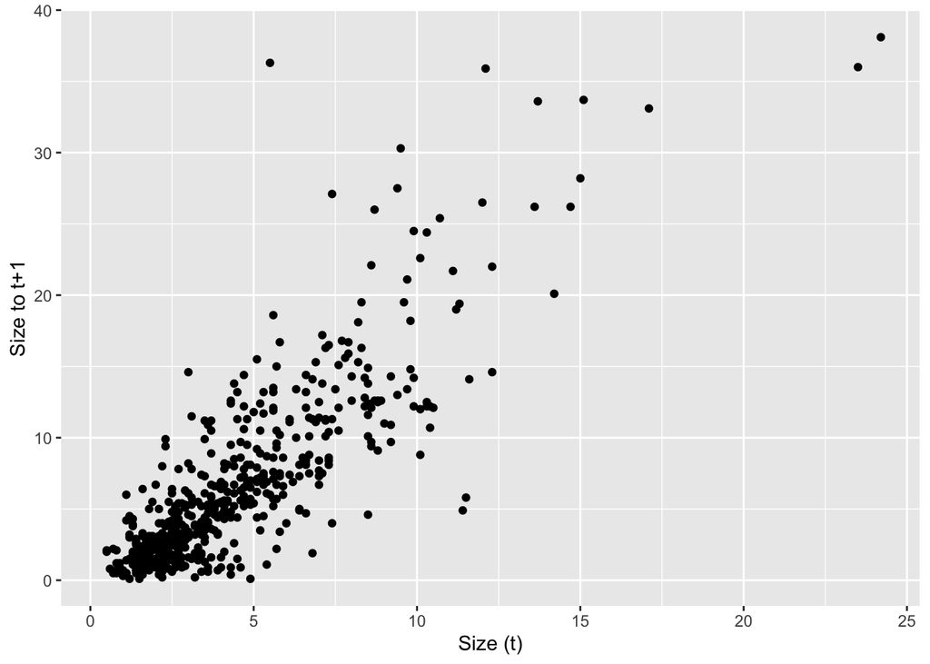

```r
sizenext.plot=ggplot(growth.7, aes(x = size, y = sizeNext))+
  geom_point()+
  xlab("Size (t)")+
  ylab("Size to t+1")
sizenext.plot
```

Make the nesting of pop.mf within parent.pop explicit in the data

```r
growth.6$pop.mf.2 = interaction(growth.6$parent.pop, growth.6$pop.mf, drop = TRUE)
```

### Survival Kernel

```r
#newdata <- expand_grid(
  #parent.pop = unique(growth.6$parent.pop),
  #pop.mf.2 = unique(growth.6$pop.mf.2),
  #block = unique(growth.6$block),
  #size = seq(min(growth.6$size, na.rm = TRUE), max(growth.6$size, na.rm = TRUE), length.out = 100))

surv.models <- tibble(name=c("0_intercept", "1_linear", "2_quadratic", "3_cubic"),
                      f = c("surv ~ 1 + (1|block) + (1|parent.pop/pop.mf)",
                            "surv ~ size + (1|block) + (1|parent.pop/pop.mf)",
                            "surv ~ size + I(size^2) + (1|block) + (1|parent.pop/pop.mf)",
                            "surv ~ size + I(size^2) + I(size^3) + (1|block) + (1|parent.pop/pop.mf)"))

surv.models <- surv.models %>%
  mutate(glmer = map(f, ~ glmer(as.formula(.), data = growth.7, family = "binomial")),
         predict = map(glmer, ~ cbind(growth.7, preds=predict(., type = "response"))),
         glance = map(glmer, tidy),
         AIC = map(glmer, AIC))
```

```
## boundary (singular) fit: see help('isSingular')
## boundary (singular) fit: see help('isSingular')
## boundary (singular) fit: see help('isSingular')
## boundary (singular) fit: see help('isSingular')
```

```r
surv.models %>% unnest(AIC)
```

```
## # A tibble: 4 × 6
##   name        f                             glmer      predict    glance     AIC
##   <chr>       <chr>                         <list>     <list>     <list>   <dbl>
## 1 0_intercept surv ~ 1 + (1|block) + (1|pa… <glmerMod> <gropd_df> <tibble> 1363.
## 2 1_linear    surv ~ size + (1|block) + (1… <glmerMod> <gropd_df> <tibble> 1360.
## 3 2_quadratic surv ~ size + I(size^2) + (1… <glmerMod> <gropd_df> <tibble> 1359.
## 4 3_cubic     surv ~ size + I(size^2) + I(… <glmerMod> <gropd_df> <tibble> 1353.
```

```r
survival.model.final = surv.models %>% filter(name == "3_cubic") %>% pull(glmer) %>% magrittr::extract2(1)
summary(survival.model.final)
```

```
## Generalized linear mixed model fit by maximum likelihood (Laplace
##   Approximation) [glmerMod]
##  Family: binomial  ( logit )
## Formula:
## surv ~ size + I(size^2) + I(size^3) + (1 | block) + (1 | parent.pop/pop.mf)
##    Data: growth.7
##
##      AIC      BIC   logLik deviance df.resid
##   1353.2   1388.0   -669.6   1339.2     1067
##
## Scaled residuals:
##     Min      1Q  Median      3Q     Max
## -2.6368 -0.7676 -0.4055  0.7990  2.2703
##
## Random effects:
##  Groups            Name        Variance  Std.Dev.
##  pop.mf:parent.pop (Intercept) 1.719e-10 1.311e-05
##  parent.pop        (Intercept) 4.888e-01 6.992e-01
##  block             (Intercept) 1.572e-01 3.965e-01
## Number of obs: 1074, groups:  pop.mf:parent.pop, 142; parent.pop, 22; block, 13
##
## Fixed effects:
##               Estimate Std. Error z value Pr(>|z|)
## (Intercept) -1.3431673  0.3322935  -4.042 5.30e-05 ***
## size         0.5619648  0.1443200   3.894 9.87e-05 ***
## I(size^2)   -0.0633950  0.0209749  -3.022  0.00251 **
## I(size^3)    0.0020907  0.0009247   2.261  0.02375 *
## ---
## Signif. codes:  0 '***' 0.001 '**' 0.01 '*' 0.05 '.' 0.1 ' ' 1
##
## Correlation of Fixed Effects:
##           (Intr) size   I(s^2)
## size      -0.748
## I(size^2)  0.569 -0.905
## I(size^3) -0.414  0.746 -0.944
## optimizer (Nelder_Mead) convergence code: 0 (OK)
## boundary (singular) fit: see help('isSingular')
```

Plot the predictions for the cubic model.

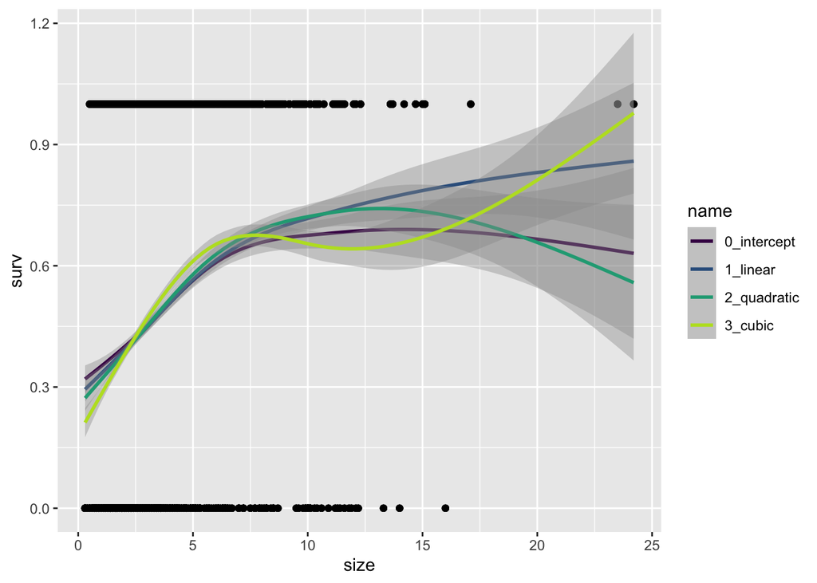

```r
surv.predictions <- surv.models %>% dplyr::select(name, predict) %>% unnest(predict)

ggplot(surv.predictions, aes(x = size, y = surv)) +
  geom_point()+
  geom_smooth(aes(y = preds, color = name))+
  scale_color_viridis_d(end = 0.9)
```

### Growth Kernel

```r
#newdata <- expand_grid(
  #parent.pop = unique(growth.6$parent.pop),
  #pop.mf.2 = unique(growth.6$pop.mf.2),
  #block = unique(growth.6$block),
  #size = seq(min(growth.6$size, na.rm = TRUE), max(growth.6$size, na.rm = TRUE), length.out = 100))

growth.8 = growth.7 %>%
  filter(!is.na(sizeNext))

growth.models <- tibble(name=c("0_intercept", "1_linear", "2_quadratic", "3_cubic"),
                      f = c("sizeNext ~ 1 + (1|block) + (1|parent.pop/pop.mf)",
                            "sizeNext ~ size + (1|block) + (1|parent.pop/pop.mf)",
                            "sizeNext ~ size + I(size^2) + (1|block) + (1|parent.pop/pop.mf)",
                            "sizeNext ~ size + I(size^2) + I(size^3) + (1|block) + (1|parent.pop/pop.mf)"))

growth.models <- growth.models %>%
  mutate(lmer = map(f, ~ lmer(as.formula(.), data = growth.8)),
         predict = map(lmer, ~ cbind(growth.8, preds=predict(.))),
         glance = map(lmer, tidy),
         AIC = map(lmer, AIC))
```

Linear best fit according to AIC

```r
growth.models %>% unnest(AIC)
```

```
## # A tibble: 4 × 6
##   name        f                              lmer      predict    glance     AIC
##   <chr>       <chr>                          <list>    <list>     <list>   <dbl>
## 1 0_intercept sizeNext ~ 1 + (1|block) + (1… <lmerMod> <gropd_df> <tibble> 2767.
## 2 1_linear    sizeNext ~ size + (1|block) +… <lmerMod> <gropd_df> <tibble> 2562.
## 3 2_quadratic sizeNext ~ size + I(size^2) +… <lmerMod> <gropd_df> <tibble> 2571.
## 4 3_cubic     sizeNext ~ size + I(size^2) +… <lmerMod> <gropd_df> <tibble> 2584.
```

```r
growth.model.final = growth.models %>% filter(name == "1_linear") %>% pull(lmer) %>% magrittr::extract2(1)
summary(growth.model.final)
```

```
## Linear mixed model fit by REML ['lmerMod']
## Formula: sizeNext ~ size + (1 | block) + (1 | parent.pop/pop.mf)
##    Data: growth.8
##
## REML criterion at convergence: 2550.1
##
## Scaled residuals:
##     Min      1Q  Median      3Q     Max
## -6.8435 -0.4623 -0.0380  0.3707  6.7119
##
## Random effects:
##  Groups            Name        Variance Std.Dev.
##  pop.mf:parent.pop (Intercept) 0.2251   0.4745
##  parent.pop        (Intercept) 8.2316   2.8691
##  block             (Intercept) 0.7119   0.8438
##  Residual                      6.8204   2.6116
## Number of obs: 515, groups:  pop.mf:parent.pop, 121; parent.pop, 22; block, 13
##
## Fixed effects:
##             Estimate Std. Error t value
## (Intercept)  1.23531    0.71464   1.729
## size         1.02357    0.06226  16.441
##
## Correlation of Fixed Effects:
##      (Intr)
## size -0.314
```

Plot the predictions for the linear model.

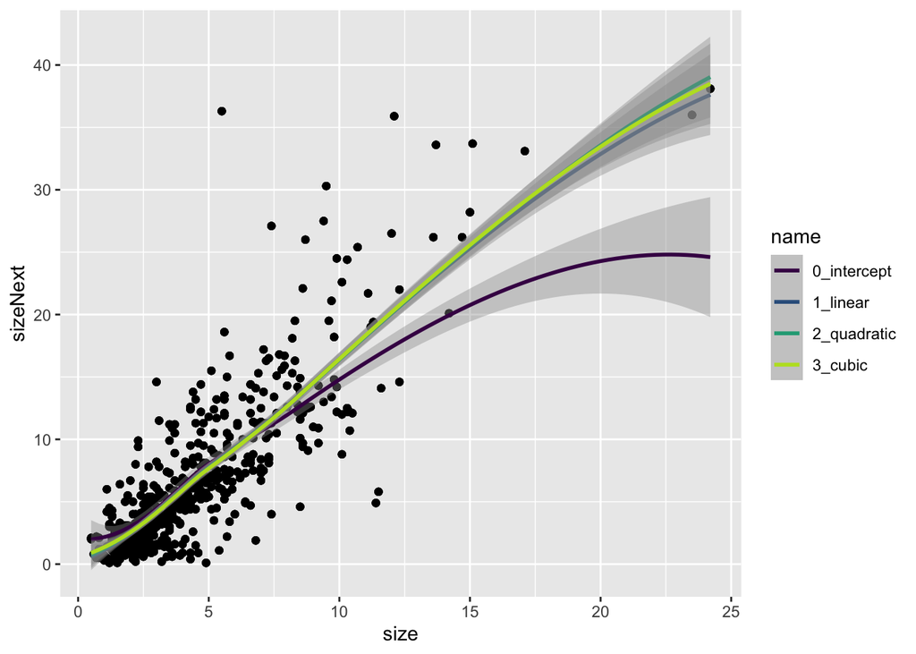

```r
growth.predictions <- growth.models %>% dplyr::select(name, predict) %>% unnest(predict)

ggplot(growth.predictions, aes(x = size, y = sizeNext)) +
  geom_point()+
  geom_smooth(aes(y = preds, color = name))+
  scale_color_viridis_d(end = 0.9)
```

### Creating the P matrix

Create dataframe for survival and growth parameters

```r
params=data.frame(
  surv.int=NA, # Intercept from logistic regression of survival
  surv.slope1=NA, # Slope from logistic regression of survival
  surv.slope2=NA, # Quadratic slope from logistic regression of survival
  surv.slope3=NA, # Cubic slope from logistic regression of survival
  growth.int=NA, # Intercept from linear regression of growth
  growth.slope=NA, # Slope from linear regression of growth
  growth.sd=NA # Residual sd from the linear regression of growth
)
```

Get survival coefficients for cubic model

```r
surv.coefs <- surv.models %>%
  filter(name == "3_cubic") %>%
  mutate(coefs = map(glmer, tidy)) %>%
  dplyr::select(name, f, coefs) %>%
  unnest(coefs)

params$surv.int <- surv.coefs %>% filter(term == "(Intercept)") %>% pull(estimate)
params$surv.slope1 <- surv.coefs %>% filter(term == "size") %>% pull(estimate)
params$surv.slope2 <- surv.coefs %>% filter(term == "I(size^2)") %>% pull(estimate)
params$surv.slope3 <- surv.coefs %>% filter(term == "I(size^3)") %>% pull(estimate)
```

Get growth coefficients from linear model

```r
growth.coefs <- growth.models %>%
  filter(name == "1_linear") %>%
  mutate(coefs = map(lmer, tidy)) %>%
  dplyr::select(name, f, coefs) %>%
  unnest(coefs)

params$growth.int <- growth.coefs %>% filter(term=="(Intercept)") %>% pull(estimate)
params$growth.slope <- growth.coefs %>% filter(term=="size") %>% pull(estimate)
params$growth.sd = sd(resid(growth.models$lmer[[2]])) # observed standard deviation
```

Set up the functions

```r
# survival probability function, this is a logistic function, provides survival probability based on size.
s.x=function(x,params) {
  u=exp(params$surv.int + params$surv.slope1*x + params$surv.slope2*x^2 + params$surv.slope3*x^3)
  return(u/(1+u))  # this is back transforming from logit
}

# growth function, this is a normal distribution, returns a probability distribution of new sizes at t+1 (xp) at a given size x.
g.yx=function(xp,x,params) {
  dnorm(xp,mean=params$growth.int+params$growth.slope*x,sd=params$growth.sd)
}
```

Make the kernel and define the parameters for integration

```r
minSize<-min(growth.7$size,na.rm=T)
maxSize<-max(growth.7$size,na.rm=T)
nBigMatrix = 80

b <- minSize + c(0:nBigMatrix) * (maxSize - minSize)/nBigMatrix # boundary points
y <- 0.5 * (b[1:nBigMatrix] + b[2:(nBigMatrix + 1)]) # mesh points
h <- y[2] - y[1] # step size
```

Make the matrix

```r
G = h*outer(y,y,g.yx,params = params) # growth matrix
# OK for each value of y,y evaluate the growth function g.yx using params
# If I understand this correctly, the rows are x(t) and the columns are x(t+1)

S = s.x(y, params = params) # survival
P = G # placeholder, redefine P on the next line
for(i in 1:nBigMatrix) P[,i] = G[,i]*S[i] # growth/survival matrix
```

Correct the matrix using the Merow et al “constant” correction code

```r
Pc = P # making a corrected matrix from already generated matrix
nvals <- colSums(Pc, na.rm = TRUE)
loc0 <- which(nvals == 0, arr.ind = TRUE)
if (length(loc0) > 0) {
      print("warnings - columns that sum to 0 or that have NAs - assuming survival is along the diagonal; plot your Pmatrix to check it")
      Pc[, loc0] <- 0
      Pc[cbind(loc0, loc0)] <- s.x(size = y[loc0], params = params)
}
nvals <- colSums(Pc, na.rm = TRUE)
Pc <- t((t(Pc)/nvals) * s.x(y, params=params))
```

Plot the corrected matrix

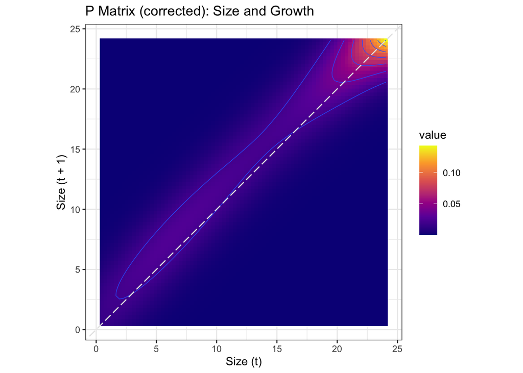

```r
Pc %>% as_tibble() %>%
  set_colnames(y) %>%
  mutate(size.t1=y) %>%
  pivot_longer(-size.t1, names_to = "size.t", names_transform = as.numeric) %>%
  ggplot(aes(x=size.t, y = size.t1)) +
  geom_raster(aes(fill = value)) +
  geom_contour(aes(z = value),lwd=.25) +
  geom_abline(intercept=0, slope = 1, color="gray90", lty=5) +
  scale_fill_viridis_c(option = "plasma") +
  labs(x = "Size (t)", y = "Size (t + 1)", title = "P Matrix (corrected): Size and Growth") +
  coord_equal() +
  theme_bw()
```